# Applied Econometrics and Data Science with R - Introduction to Tidyverse

## What are the Main Tasks in Data Wrangling?

The main tasks in data wrangling include:

1. **Data Cleaning**: Removing or correcting errors, handling missing values, and ensuring data consistency.
2. **Data Transformation**: Reshaping data, normalizing, and scaling.
3. **Data Integration**: Combining data from different sources.
4. **Data Enrichment**: Enhancing the dataset with additional information.
5. **Data Reduction**: Simplifying data without losing important information.

## How Does the Tidyverse Help?

The tidyverse is a collection of R packages designed for data science. All packages share an underlying design philosophy, grammar, and data structures. Key packages include:

- **readr**: Provides fast and friendly ways to read rectangular data see here
- **tibble**: Modern reimagining of data frames see here
- **skimr**: A very efficient way to summarise your data see here
- **dplyr**: Provides a grammar for data manipulation see here
- **tidyr**: Helps in tidying data see here
- **stringr**: Simplifies string operations see here
- **ggplot2**: A system for creating graphics – *later in the course*
- **purrr**: Enhances R’s functional programming tools – *later in the course*

It is not important to know what specific purpose a package has, but knowing about the functionalities makes your life way easier. Alternatives: base R (no packages needed!), data.table (which has another syntax and different strenghts) - see an overview of differences [here](https://mgimond.github.io/rug_2019_12/Index.html). Main advantages of the tidyverse: Data wrangling, in a nice, easily understandable way. It is also consistent with ggplot, a main tool to create nice graphs, meaning that it shares a similar syntax logic. Also, the tidyverse logic is consistent across many tidyverse-adjacent packages (see an overview [here](https://www.tidyverse.org/packages/)), and its open-source nature makes abundant sources of information available in forums. Finally, its logic is easily transferable to the most demanded data science tools in companies: pandas and sklearn libraries in python!

An essential part of the course is also to get to know the workflow of a data scientist/econometrician. An essential part is knowing where to look for solutions. To show you how integrated the tidyverse is in the R environment, go to

```
Help -> Cheat Sheet
```

and you will find a lot of nicely presented information on dplyr, ggplot2 and purrr, which are all essential parts of the tidyverse. Or you can go [here](https://posit.co/resources/cheatsheets/). Additionally, you will learn how to search for problems in forums, github, or large language models (see [here](https://gptup.uni-potsdam.de)) So let’s see how this all works in a process of constructing a dataset for analysis.

# Important packages

First, let’s load (and, before, potentially install) the packages - for now the only package we need is the tidyverse package

```r
## install packages (run only if it runs for the first time!)
# install.packages("tidyverse")

## open packages
library(tidyverse)
library(skimr)
```

Let’s start with some easy examples to show the most important functionalities of each component:

## tibble

`tibble` is a modern reimagining of data frames. It’s super similar to a data frame but has some advantages, like consistent subsetting or some default features in printing. Also it is the default data storage type of packages like `ggplot2` or `dplyr`

```r
# Example: Create a tibble, called "mytibble" with two columns: x ranging from 1 to 5 and y ranging from 6 to 10

mytibble <- tibble(
  x = 1:5,
  y = 6:10
)

mytibble
```

| x | y |
| --- | --- |
| 1 | 6 |
| 2 | 7 |
| 3 | 8 |
| 4 | 9 |
| 5 | 10 |

## dplyr

`dplyr` is used for data manipulation. It provides a set of verbs to solve common data manipulation challenges and has a user-friendly structure. `dplyr` has many functionalities:

```r
# mutate creates a new column
mutate(mytibble, z = 11:15)
```

| x | y | z |
| --- | --- | --- |
| 1 | 6 | 11 |
| 2 | 7 | 12 |
| 3 | 8 | 13 |
| 4 | 9 | 14 |
| 5 | 10 | 15 |

```r
# filter lets you filter the data based on one or more columns
filter(mytibble, y > 8)
```

| x | y |
| --- | --- |
| 4 | 9 |
| 5 | 10 |

```r
filter(mytibble, y > 8 & x > 4)
```

| x | y |
| --- | --- |
| 5 | 10 |

```r
# select lets you select certain columns
select(mytibble, y)
```

| y |
| --- |
| 6 |
| 7 |
| 8 |
| 9 |
| 10 |

Those are the basic functions of `dplyr`, but they are not its biggest strength. It’s the coherent logic across all operations and the use of piping! What does it mean?

`%>%` is the so-called piping operator, and takes a tibble or data frame as input. From there on, functions of dplyr and other tidyverse (adjacent) packages can be added and take the data after previous piping steps. It’s like taking an ingredient as an input and then continuing to work on it until the desired output.

```r
# comment out the bottom lines
mytibble %>%
  mutate(z = 11:15) %>%
  filter(y > 8) %>%
  filter(x > 4) %>%
  select(y)
```

| y |
| --- |
| 10 |

### 5-Min Classroom Task dplyr

Using the `mytibble` dataset, use piping to:

1. Create a new column `w` that is `x * y`
2. Filter to keep only rows where `w > 30`
3. Select only columns `x` and `w`

```r
# Your code here
```

Let’s turn to a little bit more exciting example and create another tibble:

```r
data <- tibble(
  "course" = c("Econ with R", "Seminar", "Seminar", "Statistics"),
  "level" = c("BA / MA", "BA", "MA", "BA"),
  "WiSe23" = c(NA, NA, "Sophie", "Sophie"),
  "SoSe24" = c(NA, "Felix", NA, "Sophie"),
  "WiSe24" = c("Felix,Sophie", NA, "Aiko", NA)
 )

data
```

| course | level | WiSe23 | SoSe24 | WiSe24 |
| --- | --- | --- | --- | --- |
| Econ with R | BA / MA | NA | NA | Felix,Sophie |
| Seminar | BA | NA | Felix | NA |
| Seminar | MA | Sophie | NA | Aiko |
| Statistics | BA | Sophie | Sophie | NA |

Who taught more courses overall, Sophie or Felix? Don’t forget that this is of course a minimum working example, so the code has to run when there are thousands of rows. Just looking at it won’t solve this task!

For that, we need to wrangle the data as it does not come in the desired format. This small task will illustrate how to:

- reshape data that is in an undesirable format (untidied!)
- create new columns
- filter a data set
- group data and create summary statistics
- work with strings in a data set
- merge two data sets

## tidyr

`tidyr` is used for tidying data, making it easier to work with. There is an amazing cheat sheet [here](https://raw.githubusercontent.com/rstudio/cheatsheets/main/tidyr.pdf).

For example, we oftentimes get information in different formats than the one needed. Oftentimes, we receive data in wide format, rather than long format.

```r
data_long <- data %>%
  pivot_longer(cols = c(WiSe23, SoSe24, WiSe24),
               names_to = "semester",
               values_to = "tutor") %>%
  separate_longer_delim(tutor, delim = ",") # careful here with the delimiter

# long data looks good
data_long
```

| course | level | semester | tutor |
| --- | --- | --- | --- |
| Econ with R | BA / MA | WiSe23 | NA |
| Econ with R | BA / MA | SoSe24 | NA |
| Econ with R | BA / MA | WiSe24 | Felix |
| Econ with R | BA / MA | WiSe24 | Sophie |
| Seminar | BA | WiSe23 | NA |
| Seminar | BA | SoSe24 | Felix |
| Seminar | BA | WiSe24 | NA |
| Seminar | MA | WiSe23 | Sophie |
| Seminar | MA | SoSe24 | NA |
| Seminar | MA | WiSe24 | Aiko |

[output cut: 3 more lines]

```r
# and we have three different tutors and some missings when no course has been taught in a given semester
unique(data_long$tutor)
```

```
## [1] NA       "Felix"  "Sophie" "Aiko"
```

`tidyr` has a lot of other great functions, but we will get to know them by doing!

Now that the data is in the correct format, we can continue with our task. We have to use the `group_by()` function to create columns that count the numbers of courses for Sophie and Felix.

```r
# missing values for tutor mean that this course has not been taught, and we're also not interested now in how many courses Aiko taught. So we can filter those out!

data_long <- data_long %>%
  filter(tutor %in% c("Sophie", "Felix"))

courses_taught <- data_long %>%
  group_by(tutor) %>%
  summarize(sum_courses = n())

courses_taught
```

| tutor | sum_courses |
| --- | --- |
| Felix | 2 |
| Sophie | 4 |

What’s the difference between `mutate()` and `summarize()`? Summarize compresses the data, it changes the dimensions and drops all other columns that have not been grouped for! It can be thought of an R-equivalent to Excel’s pivot function!

`mutate()` generates the same output per group (per tutor), but adds it as a new column! Importantly, you’d have to `ungroup()` the data before continuing to not run into problems later (if you don’t ungroup and mutate something later, it will still be calculated on the basis of the groups!)

```r
data_long %>%
  group_by(tutor) %>%
  mutate(sum_courses = n()) %>%
  ungroup()
```

| course | level | semester | tutor | sum_courses |
| --- | --- | --- | --- | --- |
| Econ with R | BA / MA | WiSe24 | Felix | 2 |
| Econ with R | BA / MA | WiSe24 | Sophie | 4 |
| Seminar | BA | SoSe24 | Felix | 2 |
| Seminar | MA | WiSe23 | Sophie | 4 |
| Statistics | BA | WiSe23 | Sophie | 4 |
| Statistics | BA | SoSe24 | Sophie | 4 |

```r
## who taught more courses that are on the master level?
data_long %>%
  mutate(master_level = as.integer(level == "MA")) %>%
  group_by(tutor) %>%
  summarize(sum_courses = sum(master_level))
```

| tutor | sum_courses |
| --- | --- |
| Felix | 0 |
| Sophie | 1 |

Is this true? What about courses that cover both Bachelor and Master levels? We can make use of the `stringr` package, which is included in the `tidyverse`

## stringr

`stringr` simplifies string operations:

```r
# Example: String manipulation
str_c("Hello", "World", sep = " ")
```

```
## [1] "Hello World"
```

```r
# this tells you whether the string "Hello" starts with the string (the letter) "H"
# str_detect("Hello", "H")

# the str_interp function comes in very handy for generating output of functions. Note that "number1" is a variable, which is added to a string

number1 <- 100
str_interp("This course is ${number1}% awesome")
```

```
## [1] "This course is 100% awesome"
```

```r
# There is a base R equivalent, which also works well in simple settings: paste()
```

So we can use a `stringr` function **within** the `dplyr` piping to create a dummy variable which equals to one if a course level includes “MA”:

```r
data_long %>%
  mutate(master_level = as.integer(str_detect(level, "MA"))) %>%
  group_by(tutor) %>%
  summarize(sum_courses = sum(master_level))
```

| tutor | sum_courses |
| --- | --- |
| Felix | 1 |
| Sophie | 2 |

```r
# alternative solution
data_long %>%
  filter(str_detect(level, "MA") == TRUE) %>%
  group_by(tutor) %>%
  summarize(sum_courses = n())
```

| tutor | sum_courses |
| --- | --- |
| Felix | 1 |
| Sophie | 2 |

Great! Finally, let’s look at another functionality of `dplyr` that is extremely important for data wrangling: Merging, or joining, data. You will in most of the projects need to combine data. Look at this simplified example, where you have information about the numbers of students in each course.

```r
number_students <- tibble(semester = c("WiSe23", "WiSe23", "SoSe24", "SoSe24", "WiSe24"),
                     course = c("Statistics", "Seminar", "Statistics", "Seminar", "Econ with R"),
                     n_students = c(170, 21, 130, 12, 20))
number_students
```

| semester | course | n_students |
| --- | --- | --- |
| WiSe23 | Statistics | 170 |
| WiSe23 | Seminar | 21 |
| SoSe24 | Statistics | 130 |
| SoSe24 | Seminar | 12 |
| WiSe24 | Econ with R | 20 |

```r
# how can we add this information to our data_long?
# we have identifiers in the data, so columns for which there is a clear match between the two data sets
# which are the identifiers? It's semester and course, so for every semester and course, there
# is a unique information of number of students

new_data_long1 <- left_join(data_long, number_students, by = c("course" = "course","semester"))
new_data_long1
```

| course | level | semester | tutor | n_students |
| --- | --- | --- | --- | --- |
| Econ with R | BA / MA | WiSe24 | Felix | 20 |
| Econ with R | BA / MA | WiSe24 | Sophie | 20 |
| Seminar | BA | SoSe24 | Felix | 12 |
| Seminar | MA | WiSe23 | Sophie | 21 |
| Statistics | BA | WiSe23 | Sophie | 170 |
| Statistics | BA | SoSe24 | Sophie | 130 |

```r
## let's try it with "course" as identifier, meaning that every value of course (e.g. "Econ with R)
## is assigned the values (note: plural) of course

new_data_long2 <- left_join(data_long, number_students, by = c("course"))
new_data_long2
```

| course | level | semester.x | tutor | semester.y | n_students |
| --- | --- | --- | --- | --- | --- |
| Econ with R | BA / MA | WiSe24 | Felix | WiSe24 | 20 |
| Econ with R | BA / MA | WiSe24 | Sophie | WiSe24 | 20 |
| Seminar | BA | SoSe24 | Felix | WiSe23 | 21 |
| Seminar | BA | SoSe24 | Felix | SoSe24 | 12 |
| Seminar | MA | WiSe23 | Sophie | WiSe23 | 21 |
| Seminar | MA | WiSe23 | Sophie | SoSe24 | 12 |
| Statistics | BA | WiSe23 | Sophie | WiSe23 | 170 |
| Statistics | BA | WiSe23 | Sophie | SoSe24 | 130 |
| Statistics | BA | SoSe24 | Sophie | WiSe23 | 170 |
| Statistics | BA | SoSe24 | Sophie | SoSe24 | 130 |

For joining, it’s crucial to understand what the unique identifiers are. Also, there are different types of joins, all of which are relevant depending on the setting. You’ll find them in the cheat sheet!

### 2-Min Classroom Task: Joining

Create a new tibble called `tutor_info` with information about each tutor:

```r
tutor_info <- tibble(
  tutor = c("Sophie", "Felix", "Aiko"),
  office = c("2.14", "2.15", "2.16")
)
```

Now join this information to `data_long` so that each course has the tutor’s office number.

```r
# Your code here
data_with_office #<-
```

What type of join did you use? What happens if you use another one instead?

# Statistics Student Survey

We are going to load our data from the previous session into R. We will again use the student survey from the introduction to statistics course. This is a csv file. The data will be loaded in a data frame.

This task will illustrate how to work with a larger data set by:

- getting a quick overview of the data
- recoding erroneous variables or variables that are not ready for quantitative analysis
- adding new variables, filtering the data set and making it easier to use by using the piping operator

## readr

Read csv file and save in tibble called `mydata`. The advantage of `readr` is that it gives some more information and lets you know if something went wrong.

```r
# use readr, which is already in the tidyverse package so we don't have to install readr separately
mydata <- read_csv(file="../00_data/survey/survey.csv")
# take a look at the data to get its size, variables and variable types. There are different ways to check how your data looks like. The most convenient ones are glimpse() and head()
head(mydata)
```

| id | geschlecht | geburtsjahr | brueder | schwestern | abiturnote | mathenote | statistiknote_w1 | fachsemester | erstfach | risk_affine | alkohol | sport | kochen | bio | paar_schuhe | job | risiko | geduldig | loc_verlauf | loc_schicksal | loc_einfluss | loc_hartearbeit | organspende | wegdauer | einkommen | partei | geburtsbundesland | fleisch | uebungen_w1 | … |
| --- | --- | --- | --- | --- | --- | --- | --- | --- | --- | --- | --- | --- | --- | --- | --- | --- | --- | --- | --- | --- | --- | --- | --- | --- | --- | --- | --- | --- | --- | --- |
| 1 | 1 | 2004 | 2 | NA | 2,50 | 270 | 2,50 | 8 | 1 | 1 | 2 | 3 | 3 | 60 | 4 | 1 | 11 | 9 | 7 | 1 | 2 | 7 | 1 | 15 | 1000 | Sonstige | 4 | 2000 | 14 | … |
| 2 | 1 | 2003 | 1 | 1 | 1,80 | 300 | 2,00 | 2 | 1 | 1 | 1 | 3 | 4 | 30 | 7 | 2 | 11 | 4 | 7 | 3 | 5 | 5 | 1 | 7 | 1800 | Grüne | NA | 2800 | 14 | … |
| 3 | 1 | 2000 | 0 | NA | 2,30 | 170 | 1,70 | 2 | 1 | 0 | 1 | 2 | 2 | 35 | 4 | 1 | 6 | 9 | 6 | 2 | 3 | 6 | 2 | 17 | 800 | SPD | 3 | 800 | 14 | … |
| 4 | 2 | 1999 | 0 | NA | 1,40 | 300 | 2,70 | 2 | 12 | 1 | 1 | 3 | 3 | 30 | 4 | 2 | 7 | 7 | 6 | 6 | 2 | 3 | 2 | 5 | 400 | Keine | 2 | 150 | 13 | … |
| 5 | 1 | 2004 | 0 | 3 | 2,40 | 500 | 2,00 | 2 | 12 | 0 | 1 | 2 | 3 | 50 | 2 | 2 | 5 | 9 | 6 | 2 | 4 | 7 | 1 | 60 | 900 | Linke | 10 | 10 | 14 | … |
| 6 | 2 | 2005 | NA | 1 | 2,20 | NA | 3,70 | 6 | 17 | 0 | 1 | 1 | 3 | 25 | 12 | 1 | 4 | 8 | 6 | 2 | 3 | 6 | NA | 90 | NA | Grüne | 4 | 500 | 14 | … |

The data set already looks quite tidy. It is in rectangular shape and has one observation per row and year. Let’s get some more information for a first impression:

## skimr

```r
skim(mydata)
```

Data summary

| Name | mydata |
| --- | --- |
| Number of rows | 266 |
| Number of columns | 32 |
| _______________________ |  |
| Column type frequency: |  |
| character | 5 |
| numeric | 27 |
| ________________________ |  |
| Group variables | None |

**Variable type: character**

| skim_variable | n_missing | complete_rate | min | max | empty | n_unique | whitespace |
| --- | --- | --- | --- | --- | --- | --- | --- |
| abiturnote | 12 | 0.95 | 4 | 4 | 0 | 28 | 0 |
| statistiknote_w1 | 17 | 0.94 | 4 | 4 | 0 | 19 | 0 |
| partei | 0 | 1.00 | 3 | 8 | 0 | 7 | 0 |
| Partei | 0 | 1.00 | 3 | 8 | 0 | 7 | 0 |
| geburtsbundesland_name | 37 | 0.86 | 6 | 22 | 0 | 14 | 0 |

**Variable type: numeric**

| skim_variable | n_missing | complete_rate | mean | sd | p0 | p25 | p50 | p75 | p100 | hist |
| --- | --- | --- | --- | --- | --- | --- | --- | --- | --- | --- |
| id | 0 | 1.00 | 1.33500e+02 | 7.693000e+01 | 1 | 67.25 | 133.5 | 199.75 | 2.6600e+02 | ▇▇▇▇▇ |
| geschlecht | 6 | 0.98 | 1.41000e+00 | 5.200000e-01 | 1 | 1.00 | 1.0 | 2.00 | 3.0000e+00 | ▇▁▅▁▁ |
| geburtsjahr | 8 | 0.97 | 2.00155e+03 | 5.200000e+00 | 1972 | 2000.00 | 2002.0 | 2004.00 | 2.0500e+03 | ▁▇▃▁▁ |
| brueder | 75 | 0.72 | 5.42600e+01 | 7.234400e+02 | 0 | 0.00 | 1.0 | 1.00 | 9.9990e+03 | ▇▁▁▁▁ |
| schwestern | 77 | 0.71 | 5.45300e+01 | 7.272300e+02 | -1 | 0.00 | 1.0 | 1.00 | 9.9990e+03 | ▇▁▁▁▁ |
| mathenote | 67 | 0.75 | 3.60100e+02 | 1.282900e+02 | 100 | 270.00 | 370.0 | 500.00 | 5.0000e+02 | ▂▂▆▃▇ |
| fachsemester | 11 | 0.96 | 3.39000e+00 | 2.040000e+00 | 2 | 2.00 | 2.0 | 4.00 | 8.0000e+00 | ▇▂▁▁▂ |
| erstfach | 0 | 1.00 | 1.29400e+01 | 2.647000e+01 | 1 | 1.00 | 2.0 | 12.00 | 9.9000e+01 | ▇▁▁▁▁ |
| risk_affine | 17 | 0.94 | 5.40000e-01 | 5.000000e-01 | 0 | 0.00 | 1.0 | 1.00 | 1.0000e+00 | ▇▁▁▁▇ |
| alkohol | 16 | 0.94 | 1.69000e+00 | 8.000000e-01 | 1 | 1.00 | 2.0 | 2.00 | 5.0000e+00 | ▇▇▂▁▁ |
| sport | 15 | 0.94 | 2.68000e+00 | 1.070000e+00 | 1 | 2.00 | 3.0 | 3.00 | 5.0000e+00 | ▃▇▇▃▂ |
| kochen | 15 | 0.94 | 3.26000e+00 | 1.210000e+00 | 1 | 2.00 | 3.0 | 4.00 | 5.0000e+00 | ▂▆▇▅▆ |
| bio | 21 | 0.92 | 3.16900e+01 | 2.210000e+01 | 0 | 15.00 | 30.0 | 45.00 | 1.0000e+02 | ▇▆▃▂▁ |
| paar_schuhe | 20 | 0.92 | 1.07400e+01 | 4.136000e+01 | 1 | 4.00 | 6.0 | 10.00 | 6.4500e+02 | ▇▁▁▁▁ |
| job | 18 | 0.93 | 1.36000e+00 | 4.800000e-01 | 1 | 1.00 | 1.0 | 2.00 | 2.0000e+00 | ▇▁▁▁▅ |
| risiko | 17 | 0.94 | 6.60000e+00 | 2.180000e+00 | 1 | 5.00 | 7.0 | 8.00 | 1.1000e+01 | ▃▅▇▇▂ |
| geduldig | 20 | 0.92 | 6.36000e+00 | 2.380000e+00 | 1 | 4.00 | 7.0 | 8.00 | 1.1000e+01 | ▃▆▆▇▂ |
| loc_verlauf | 17 | 0.94 | 5.53000e+00 | 1.150000e+00 | 1 | 5.00 | 6.0 | 6.00 | 7.0000e+00 | ▁▁▂▃▇ |
| loc_schicksal | 16 | 0.94 | 3.19000e+00 | 1.550000e+00 | 1 | 2.00 | 3.0 | 4.00 | 7.0000e+00 | ▇▆▃▂▂ |
| loc_einfluss | 16 | 0.94 | 2.75000e+00 | 1.380000e+00 | 1 | 2.00 | 2.0 | 3.00 | 7.0000e+00 | ▇▃▂▂▁ |
| loc_hartearbeit | 16 | 0.94 | 5.48000e+00 | 1.330000e+00 | 1 | 5.00 | 6.0 | 6.00 | 7.0000e+00 | ▁▁▂▃▇ |
| organspende | 16 | 0.94 | 1.68000e+00 | 4.700000e-01 | 1 | 1.00 | 2.0 | 2.00 | 2.0000e+00 | ▃▁▁▁▇ |
| wegdauer | 10 | 0.96 | 3.93466e+08 | 6.249987e+09 | 1 | 25.00 | 40.0 | 55.00 | 1.0000e+11 | ▇▁▁▁▁ |
| einkommen | 43 | 0.84 | 1.57408e+03 | 6.359760e+03 | 0 | 617.50 | 1000.0 | 1400.00 | 9.3567e+04 | ▇▁▁▁▁ |
| geburtsbundesland | 37 | 0.86 | 4.68000e+00 | 3.130000e+00 | 1 | 3.00 | 3.0 | 4.00 | 1.6000e+01 | ▇▁▁▁▁ |
| fleisch | 24 | 0.91 | 2.99297e+04 | 4.499369e+05 | 0 | 50.00 | 400.0 | 800.00 | 7.0000e+06 | ▇▁▁▁▁ |
| uebungen_w1 | 14 | 0.95 | 1.23500e+01 | 2.570000e+00 | 0 | 12.00 | 13.0 | 14.00 | 1.4000e+01 | ▁▁▁▂▇ |

We want to see whether students who are more risk affine are more likely to have better expectations about their statistics exam outcome.

## dplyr

School grade and expected statistics grade should not be characters but numerical variables!

```r
# what's happening here?
as.numeric(mydata$abiturnote)
```

```
##   [1] NA NA NA NA NA NA NA NA NA NA NA NA NA NA NA NA NA NA NA NA NA NA NA NA NA
##  [26] NA NA NA NA NA NA NA NA NA NA NA NA NA NA NA NA NA NA NA NA NA NA NA NA NA
##  [51] NA NA NA NA NA NA NA NA NA NA NA NA NA NA NA NA NA NA NA NA NA NA NA NA NA
##  [76] NA NA NA NA NA NA NA NA NA NA NA NA NA NA NA NA NA NA NA NA NA NA NA NA NA
## [101] NA NA NA NA NA NA NA NA NA NA NA NA NA NA NA NA NA NA NA NA NA NA NA NA NA
## [126] NA NA NA NA NA NA NA NA NA NA NA NA NA NA NA NA NA NA NA NA NA NA NA NA NA
## [151] NA NA NA NA NA NA NA NA NA NA NA NA NA NA NA NA NA NA NA NA NA NA NA NA NA
## [176] NA NA NA NA NA NA NA NA NA NA NA NA NA NA NA NA NA NA NA NA NA NA NA NA NA
## [201] NA NA NA NA NA NA NA NA NA NA NA NA NA NA NA NA NA NA NA NA NA NA NA NA NA
## [226] NA NA NA NA NA NA NA NA NA NA NA NA NA NA NA NA NA NA NA NA NA NA NA NA NA
## [251] NA NA NA NA NA NA NA NA NA NA NA NA NA NA NA NA
```

```r
mydata <- mydata %>%
  mutate(abiturnote = as.numeric(str_replace(abiturnote, ",", "")),
         statistiknote_w1 = as.numeric(str_replace(statistiknote_w1, ",", "")))
head(mydata)
```

| id | geschlecht | geburtsjahr | brueder | schwestern | abiturnote | mathenote | statistiknote_w1 | fachsemester | erstfach | risk_affine | alkohol | sport | kochen | bio | paar_schuhe | job | risiko | geduldig | loc_verlauf | loc_schicksal | loc_einfluss | loc_hartearbeit | organspende | wegdauer | einkommen | partei | geburtsbundesland | fleisch | uebungen_w1 | … |
| --- | --- | --- | --- | --- | --- | --- | --- | --- | --- | --- | --- | --- | --- | --- | --- | --- | --- | --- | --- | --- | --- | --- | --- | --- | --- | --- | --- | --- | --- | --- |
| 1 | 1 | 2004 | 2 | NA | 250 | 270 | 250 | 8 | 1 | 1 | 2 | 3 | 3 | 60 | 4 | 1 | 11 | 9 | 7 | 1 | 2 | 7 | 1 | 15 | 1000 | Sonstige | 4 | 2000 | 14 | … |
| 2 | 1 | 2003 | 1 | 1 | 180 | 300 | 200 | 2 | 1 | 1 | 1 | 3 | 4 | 30 | 7 | 2 | 11 | 4 | 7 | 3 | 5 | 5 | 1 | 7 | 1800 | Grüne | NA | 2800 | 14 | … |
| 3 | 1 | 2000 | 0 | NA | 230 | 170 | 170 | 2 | 1 | 0 | 1 | 2 | 2 | 35 | 4 | 1 | 6 | 9 | 6 | 2 | 3 | 6 | 2 | 17 | 800 | SPD | 3 | 800 | 14 | … |
| 4 | 2 | 1999 | 0 | NA | 140 | 300 | 270 | 2 | 12 | 1 | 1 | 3 | 3 | 30 | 4 | 2 | 7 | 7 | 6 | 6 | 2 | 3 | 2 | 5 | 400 | Keine | 2 | 150 | 13 | … |
| 5 | 1 | 2004 | 0 | 3 | 240 | 500 | 200 | 2 | 12 | 0 | 1 | 2 | 3 | 50 | 2 | 2 | 5 | 9 | 6 | 2 | 4 | 7 | 1 | 60 | 900 | Linke | 10 | 10 | 14 | … |
| 6 | 2 | 2005 | NA | 1 | 220 | NA | 370 | 6 | 17 | 0 | 1 | 1 | 3 | 25 | 12 | 1 | 4 | 8 | 6 | 2 | 3 | 6 | NA | 90 | NA | Grüne | 4 | 500 | 14 | … |

```r
## use dplyr's "mutate" function and the piping to create new columns: age, has_siblings, female, and easier-to-digest versions of grades (2.7 instead of 270), as well as organ_donor
## We can mutate more than one variable at the same time!

mydata <- mydata %>% mutate(age = year(today()) - geburtsjahr,
                             female = as.factor(if_else(geschlecht == 2, 1, 0, missing = NA)),
                             male = as.factor(if_else(geschlecht == 1, 1, 0, missing = NA)),
                             has_siblings = as.factor(if_else(brueder > 0 | schwestern > 0, 1, 0, missing = 0)),
                             abiturnote = abiturnote / 100,
                             statistiknote_w1 = statistiknote_w1 / 100,
                             mathenote = mathenote / 100,
                             organ_donor = as.factor(if_else(organspende == 2, 1, 0)),
                             sidejob = as.factor(if_else(job == 1, 1, 0, missing = NA)))

# drop the variables from which you constructed the new variables
mydata <- mydata %>% select(-c(geschlecht:schwestern), - organspende, - job)
head(mydata)
```

| id | abiturnote | mathenote | statistiknote_w1 | fachsemester | erstfach | risk_affine | alkohol | sport | kochen | bio | paar_schuhe | risiko | geduldig | loc_verlauf | loc_schicksal | loc_einfluss | loc_hartearbeit | wegdauer | einkommen | partei | geburtsbundesland | fleisch | uebungen_w1 | Partei | geburtsbundesland_name | age | female | male | has_siblings | … |
| --- | --- | --- | --- | --- | --- | --- | --- | --- | --- | --- | --- | --- | --- | --- | --- | --- | --- | --- | --- | --- | --- | --- | --- | --- | --- | --- | --- | --- | --- | --- |
| 1 | 2.5 | 2.7 | 2.5 | 8 | 1 | 1 | 2 | 3 | 3 | 60 | 4 | 11 | 9 | 7 | 1 | 2 | 7 | 15 | 1000 | Sonstige | 4 | 2000 | 14 | Sonstige | Brandenburg | 21 | 0 | 1 | 1 | … |
| 2 | 1.8 | 3.0 | 2.0 | 2 | 1 | 1 | 1 | 3 | 4 | 30 | 7 | 11 | 4 | 7 | 3 | 5 | 5 | 7 | 1800 | Grüne | NA | 2800 | 14 | Grüne | NA | 22 | 0 | 1 | 1 | … |
| 3 | 2.3 | 1.7 | 1.7 | 2 | 1 | 0 | 1 | 2 | 2 | 35 | 4 | 6 | 9 | 6 | 2 | 3 | 6 | 17 | 800 | SPD | 3 | 800 | 14 | SPD | Berlin | 25 | 0 | 1 | 0 | … |
| 4 | 1.4 | 3.0 | 2.7 | 2 | 12 | 1 | 1 | 3 | 3 | 30 | 4 | 7 | 7 | 6 | 6 | 2 | 3 | 5 | 400 | Keine | 2 | 150 | 13 | Keine | Bayern | 26 | 1 | 0 | 0 | … |
| 5 | 2.4 | 5.0 | 2.0 | 2 | 12 | 0 | 1 | 2 | 3 | 50 | 2 | 5 | 9 | 6 | 2 | 4 | 7 | 60 | 900 | Linke | 10 | 10 | 14 | Linke | Nordrhein-Westfalen | 21 | 0 | 1 | 1 | … |
| 6 | 2.2 | NA | 3.7 | 6 | 17 | 0 | 1 | 1 | 3 | 25 | 12 | 4 | 8 | 6 | 2 | 3 | 6 | 90 | NA | Grüne | 4 | 500 | 14 | Grüne | Brandenburg | 20 | 1 | 0 | 1 | … |

The data set now consists of new variable that have information more easily digestable for coding and modelling. It also drops the variables that are not needed anymore, resulting in less variables, which has some benefits in working with it (faster, easier to understand what’s happening). Now lets create some variables!

```r
mydata <- mydata %>%
  mutate(erstfach_name = case_when(erstfach == 1 ~ "BWL",
                                   erstfach == 2 ~  "VWL" ,
                                   erstfach == 7 ~  "Jura",
                                   erstfach == 11 ~  "Spanische Philologie",
                                   erstfach == 12 ~ "Politik und Wirtschaft",
                                   erstfach == 17 ~ "Wirtschaftsinformatik",
                                   erstfach == 18 ~ "Philosophie",
                                   erstfach == 23 ~ "Politikwissenschaft"))
```

### 5-Min Classroom Task 3

**Hint:** Use `mutate()`, `filter()`, `group_by()`, and `summarize()`

```r
# Your code here
```

# Missing values

We created some variables and are relatively good to go, but there are some things that seem off. First, there is a lot of missing values for the math grade, there are some missing values for statistics grade (our outcome) and risk affinity and there are people with a negative age (we could have noticed before). So let’s take care of those.

```r
## drop observations where the statistics grade is missing, where risk affinity is missing and keep only observations with positive age.
mydata <- mydata %>%
  filter(age > 0) %>%
  drop_na(risk_affine, statistiknote_w1)
```

Do we really want to just drop missing variables? For example, look at the math grade. There, this is a little more tricky. Missings for the math grade mean that this person has not yet taken the math grade. Does this mean that we should drop this observation? We would probably lose a lot of information there. On the other hand, imputing may create variation that is not there. Every discipline has its own “best practice” of dealing with missing variables. This is an important task in the analysis. In prediction tasks, particularly in business contexts, missing values are oftentimes imputed. Oftentimes in economics, missing values are dropped. If using surveys, this may however mean that certain individuals were not answering a specific question. Does this affect the results? If so, what are the conditions that need to be fulfilled that it doesn’t? Particularly in such contexts, you’d have to provide evidence that it does not change the analysis.

There are some approaches that are more and less common, and some are completely safe. Let’s have a look at different approaches:

## Imputation

If you have missing values, you may be able to impute them. Common ways are mean imputation or median imputation. Look at this example:

```r
# impute missing values in math grade with the group average of students in each field of study who already took the exam
mydata <- mydata %>% group_by(erstfach_name) %>% mutate(avg_mathenote = mean(mathenote, na.rm = T)) %>% ungroup()
```

With mean imputation, we would give all values with a missing `mathenote` the average value of `mathenote`:

```r
mydata <- mydata %>% mutate(mathenote = if_else(is.na(mathenote), avg_mathenote, mathenote),
                             mathenote = replace_na(mathenote, mean(mathenote, na.rm = T)))
```

This may make more sense with grouped means, for example by subject of study. This way, we would give all values with a missing `mathenote` the average value of `mathenote` within each subject. Median imputation works similar, but imputes the median.

What are downsides? You create variation that may not be there, and you want to be really careful with this. There are safe ways to impute, though. Think about this: You run a survey (like the SOEP), interview people repeatedly over the years. In one year, you ask them about their year of birth. In the next year, you don’t. Since the birth year is **time-invariant**, you can easily impute it for each person!

## Filling Time-Invariant Variables

Sometimes you have variables that should be constant for each person (like year of birth, gender, or place of birth), but have missing values in some observations. If you have panel data or repeated observations, you can use `fill()` to copy non-missing values within groups.

Let’s create an example to demonstrate this:

```r
# Create example data where some students have missing birth years
example_data <- tibble(
  student_id = c(1, 1, 1, 2, 2, 2, 3, 3, 3),
  semester = c("WiSe23", "SoSe24", "WiSe24", "WiSe23", "SoSe24", "WiSe24", "WiSe23", "SoSe24", "WiSe24"),
  geburtsjahr = c(2000, NA, NA, NA, 1999, NA, 2001, 2001, 2001),
  grade = c(2.0, 1.7, 1.3, 2.3, 2.0, 1.7, 1.0, 1.3, 1.7)
)

example_data
```

| student_id | semester | geburtsjahr | grade |
| --- | --- | --- | --- |
| 1 | WiSe23 | 2000 | 2.0 |
| 1 | SoSe24 | NA | 1.7 |
| 1 | WiSe24 | NA | 1.3 |
| 2 | WiSe23 | NA | 2.3 |
| 2 | SoSe24 | 1999 | 2.0 |
| 2 | WiSe24 | NA | 1.7 |
| 3 | WiSe23 | 2001 | 1.0 |
| 3 | SoSe24 | 2001 | 1.3 |
| 3 | WiSe24 | 2001 | 1.7 |

Notice that student 1 has birth year only in the first observation, student 2 only in the second, and student 3 has it in all observations. Since birth year is time-invariant (doesn’t change!), we can fill the missing values within each student:

```r
# Fill missing birth years within each student
example_data_filled <- example_data %>%
  group_by(student_id) %>% # to apply the filling by student
  fill(geburtsjahr, .direction = "downup") %>%  # fills in both directions, so it works regardless of where the non-missing value is. other options are "up" or "down", or "downup"
  ungroup()

example_data_filled
```

| student_id | semester | geburtsjahr | grade |
| --- | --- | --- | --- |
| 1 | WiSe23 | 2000 | 2.0 |
| 1 | SoSe24 | 2000 | 1.7 |
| 1 | WiSe24 | 2000 | 1.3 |
| 2 | WiSe23 | 1999 | 2.3 |
| 2 | SoSe24 | 1999 | 2.0 |
| 2 | WiSe24 | 1999 | 1.7 |
| 3 | WiSe23 | 2001 | 1.0 |
| 3 | SoSe24 | 2001 | 1.3 |
| 3 | WiSe24 | 2001 | 1.7 |

This is extremely useful when: - You have longitudinal/panel data - Time-invariant characteristics have missing values in some periods - You want to avoid dropping entire observations just because one period is missing

## Handling Non-Numeric Variables

Many datasets have non-numeric variables. In this example, `job`, `erstfach_name` and `partei` are categorical variables. Some algorithms only work with numerical data and cannot directly handle categorical variables. Think back about how you treated categorical variables in linear regression. Here are the options:

- **Solutions**:
  - **Binary encoding**: Convert binary variables (e.g., `job`) into 0 (no job) and 1 (has a job). (We have already done this!)
  - **One-hot encoding**: For variables with multiple categories (e.g., `erstfach_name`), create a separate binary column for each category (e.g., BWL = 1 only if erstfach_name == BWL, else 0, Wirtschaftsinformatik = 1 only if … ).

```r
# four dimensions and one group
# One-hot encode the 'erstfach_name' variable
library(fastDummies)
mydata_one_hot <- dummy_cols(mydata, select_columns = "erstfach_name", remove_first_dummy = TRUE, remove_selected_columns = TRUE)
```

Sometimes, it makes sense to group very small categories into a larger category. This way, you **avoid having a dummy group with only a small number of observations**

# Outliers

Let’s see how we can deal with outliers.

```r
## Remove outliers
skim(mydata %>% select(wegdauer, paar_schuhe, einkommen)) # some values seem unreasonable
```

Data summary

| Name | mydata %>% select(wegdaue… |
| --- | --- |
| Number of rows | 235 |
| Number of columns | 3 |
| _______________________ |  |
| Column type frequency: |  |
| numeric | 3 |
| ________________________ |  |
| Group variables | None |

**Variable type: numeric**

| skim_variable | n_missing | complete_rate | mean | sd | p0 | p25 | p50 | p75 | p100 | hist |
| --- | --- | --- | --- | --- | --- | --- | --- | --- | --- | --- |
| wegdauer | 0 | 1.00 | 428626820.05 | 6.52325e+09 | 1 | 25 | 35 | 55 | 1.0000e+11 | ▇▁▁▁▁ |
| paar_schuhe | 3 | 0.99 | 10.96 | 4.25700e+01 | 1 | 4 | 6 | 10 | 6.4500e+02 | ▇▁▁▁▁ |
| einkommen | 39 | 0.83 | 1534.41 | 6.64025e+03 | 0 | 650 | 1000 | 1400 | 9.3567e+04 | ▇▁▁▁▁ |

```r
mydata_outliers <- mydata %>% filter(wegdauer < 1000, paar_schuhe < 100, einkommen < 10000)
```

We just removed some outliers! But how did we decide on what values to remove? And why would we care about outliers?

Outliers are data points that differ significantly from other observations. They can arise due to different reasons, like measurement errors, natural variation like billionaires in income data, or “funnily overstated” answers in surveys.

Outlier detection is super important because outliers can heavily influence regression coefficients and predictions. Regressions are mean-based, so outliers highly affect the outcome. In classification, outliers may cause misclassification or increase model complexity. There is a common example in basic statistics, [“when Bill Gates walks in to a bar”](https://introductorystats.wordpress.com/2011/09/04/when-bill-gates-walks-into-a-bar/):

One way to detect outliers is to vizualise them, for example with a boxplot.

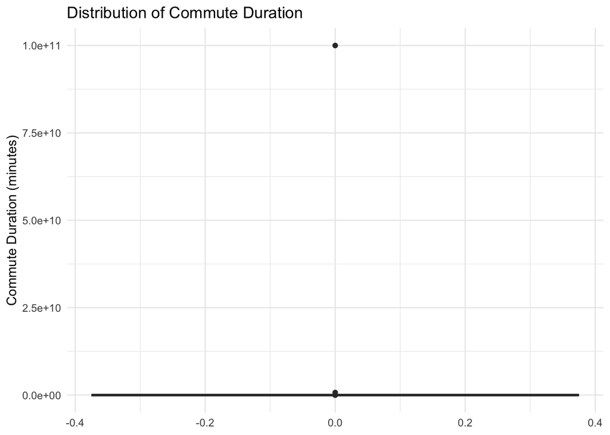

```r
# Boxplot of commute duration
## base R:
# boxplot(mydata$wegdauer)
ggplot(mydata, aes(y = wegdauer)) +
  geom_boxplot(fill = "#4BADA9") +
  labs(title = "Distribution of Commute Duration",
       y = "Commute Duration (minutes)") +
  theme_minimal()
```

Apparently, some student lives really really far away.

```r
# Look at extreme values
mydata %>%
  select(wegdauer) %>%
  arrange(desc(wegdauer)) %>%
  head(10)
```

| wegdauer |
| --- |
| 99999999999 |
| 727283499 |
| 9999 |
| 105 |
| 100 |
| 100 |
| 100 |
| 90 |
| 90 |
| 90 |

Most probably, though, that’s just a non-serious answer.

Histograms show the distribution more clearly:

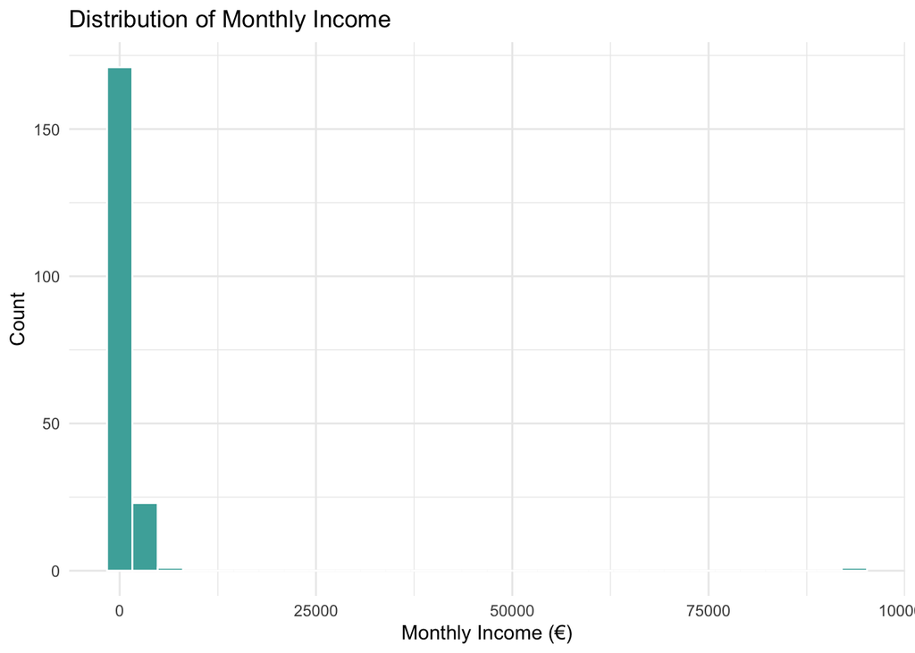

```r
# Histogram of income
ggplot(mydata, aes(x = einkommen)) +
  geom_histogram(bins = 30, fill = "#4BADA9", color = "white") +
  labs(title = "Distribution of Monthly Income",
       x = "Monthly Income (€)",
       y = "Count") +
  theme_minimal()
```

Let’s see what’s happening there:

```r
# Check extreme values
mydata %>%
  select(einkommen) %>%
  arrange(desc(einkommen)) %>%
  head(10)
```

| einkommen |
| --- |
| 93567 |
| 5000 |
| 4000 |
| 2825 |
| 2700 |
| 2520 |
| 2500 |
| 2500 |
| 2300 |
| 2200 |

### 5-Min Classroom Task: Outliers

Create a boxplot for the `paar_schuhe` (number of pairs of shoes) variable.

1. Create a boxplot
2. Look at the top 10 values using `arrange(desc(paar_schuhe))`
3. What do you think - are there outliers? Are they plausible?

```r
# Your code here
```

So how do we decide if a point (or many points) should be removed or transformed? First, like in the `wegdauer` example, you can ask your “gut feeling”, or common sense. What’s a range that’s reasonable? Does it make sense in this context? Is a student really making almost 100k a month? If it is so, will this affect my estimation?

There are also more technical approaches. Sometimes we don’t have strong prior knowledge about what’s “reasonable”. In that case, we can remove the most extreme values statistically by keeping only observations between certain percentiles.

**Common choice in economics:** Keep only data between the 5th and 95th percentiles, or until the 95th percentile (removes top and bottom 5%, or top 5%). Alternatively, you can cap the date. This means that you assign all the values above the 95th percentile the value of the 95th percentile.

```r
# Calculate 95th percentiles for wegdauer
p95_wegdauer <- quantile(mydata$wegdauer, 0.95, na.rm = TRUE)

# Filter data
mydata_percentile <- mydata %>%
  filter(wegdauer <= p95_wegdauer)
```

There are also more sophisticated statistical methods for detecting outliers:

**IQR Method (Interquartile Range):** - Based on the boxplot rule: values beyond 1.5 × IQR from the quartiles - Less aggressive than percentiles - Good for symmetric distributions

**Z-Score Method:** - Measures how many standard deviations away from the mean - Typically use |z| > 3 as threshold - Assumes normally distributed data

| Method | Description | Issues |
| --- | --- | --- |
| **Removal** | Exclude rows with outliers. | Risks discarding valid but extreme observations, reducing sample size. |
| **Capping** | Replace extreme values with thresholds. | Arbitrary thresholds may distort data distribution. |
| **Transformation** | Apply log, square root, or other transformations. | Can oversimplify relationships or make interpretation more complex. |
| **Keeping** | You don’t do anything because interesting information may be in outliers | Your estimates or predictions may be heavily distorted, depending of the importance of the outliers |

In the next session, we will need the cleaner version of our student survey. For that, let’s save the current version of `mydata` as a csv-file called `survey_processed.csv`

```r
write_csv(mydata, "../00_data/survey/survey_processed.csv")
```

### 10-Min Classroom Task: Complete Data Wrangling Pipeline

Using the **original** `mydata` (reload it with `read_csv()` if needed), create a complete pipeline that:

1. Converts `abiturnote` and `statistiknote_w1` to numeric (remove commas and divide by 100)
2. Creates a variable `young_student` that equals 1 if the student is 22 or younger
3. Filters to keep only students who have `risk_affine` information and are younger than 35
4. Groups by `erstfach` (field of study) and calculates:
   - The average `statistiknote_w1`
   - The proportion of `young_student`
   - The number of students (`n()`)
5. Arranges the results by average statistics grade (best to worst)

**Challenge:** Do this all in ONE piping chain!

```r
# Your code here - reload data first
mydata <- read_csv(file="../00_data/survey/survey.csv")
```

# Summary

The great thing about the `tidyverse` is: We can stack a lot of those operations on top of each other. The piping operator *%>%* takes the previous, already manipulated data and applies the function! Also, the piping operator is not sensitive to new lines, so it’s super easy to write well-structured data manipulation.

**What we learned:**

- **Packages** extend R’s functionality - install once, load with `library()`
- **Tidyverse** is a collection of packages for data science
- **Tidy data** has variables in columns, observations in rows
- **Key tidyverse tools:**
  - `readr`: Read data
  - `tibble`: Modern data frames
  - `dplyr`: Manipulate data (mutate, filter, select, group_by, summarize)
  - `tidyr`: Reshape data (pivot_longer, pivot_wider)
  - `stringr`: Work with strings
- **Piping (`%>%`)**: Chain operations together for readable code
- **Data wrangling**: Clean, transform, and prepare data for analysis

# Sources

- Wickham, H., & Grolemund, G. (2017). *R for Data Science*. O’Reilly Media. Available at https://r4ds.had.co.nz/
- Wickham, H., et al. (2019). Welcome to the Tidyverse. *Journal of Open Source Software*, 4(43), 1686. https://doi.org/10.21105/joss.01686
- RStudio. (n.d.). *Tidyverse Cheat Sheets*. Retrieved from https://posit.co/resources/cheatsheets/
- Wickham, H. (n.d.). *Tidy Data*. Retrieved from https://r4ds.had.co.nz/tidy-data.html